# Reproducible Research: Peer Assessment 1

Anurati Chatty

10/01/2021

## R Markdown for peer review

This is an R markdown generated for the Reproducible Research peer review assesment 1.

## Loading and preprossesing the data

Load the data and store it in activity

```r
library(dplyr)
activity <- read.csv("activity.csv")
head(activity)
```

```
##   steps       date interval
## 1    NA 2012-10-01        0
## 2    NA 2012-10-01        5
## 3    NA 2012-10-01       10
## 4    NA 2012-10-01       15
## 5    NA 2012-10-01       20
## 6    NA 2012-10-01       25
```

```r
activity$date <- as.Date(activity$date,"%Y-%m-%d")
```

## What is mean total number of steps taken per day?

First we calculate the totaal number of steps taken per day using tapply

```r
steps_day <- tapply(activity$steps,activity$date,sum,na.rm=TRUE)
```

Second plotting the histogram for number of steps taken per day

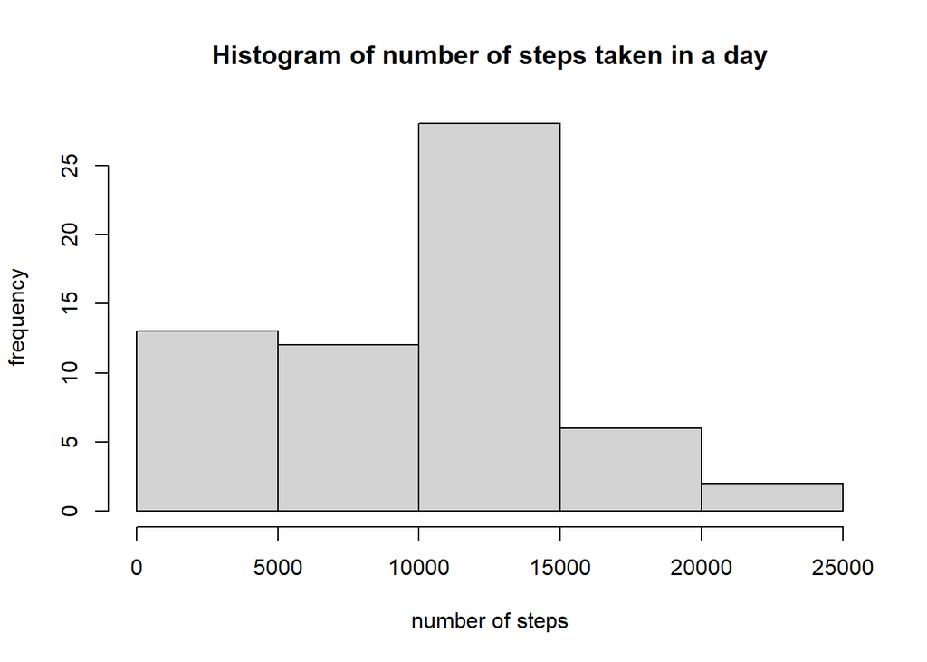

```r
hist(steps_day, xlab = "number of steps", ylab="frequency", main="Histogram of number of steps taken in a day")
```

Barplot

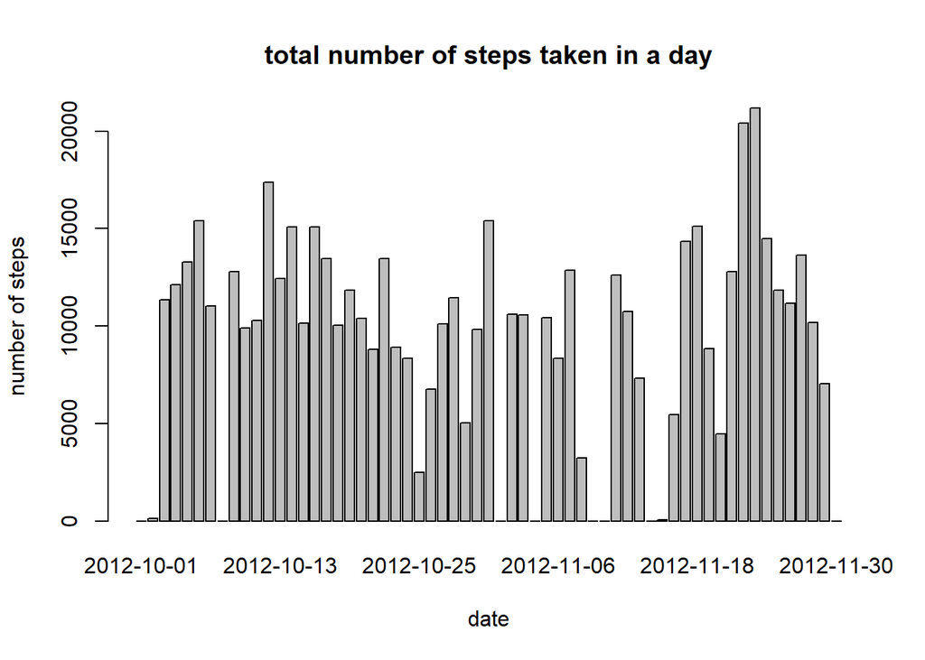

```r
barplot(height = steps_day, xlab = "date", ylab = "number of steps", main = "total number of steps taken in a day")
```

Mean of total number of steps taken per day

```r
mean(steps_day)
```

```
## [1] 9354.23
```

Median of total number of steps taken per day

```r
median(steps_day)
```

```
## [1] 10395
```

## What is the average daily activity pattern?

Making a time series plot of 5 minute intervals and the average number of steps taken, averaged across all days

```r
day_mean <- tapply(activity$steps,activity$interval , mean, na.rm=TRUE)
head(day_mean)
```

```
##         0         5        10        15        20        25
## 1.7169811 0.3396226 0.1320755 0.1509434 0.0754717 2.0943396
```

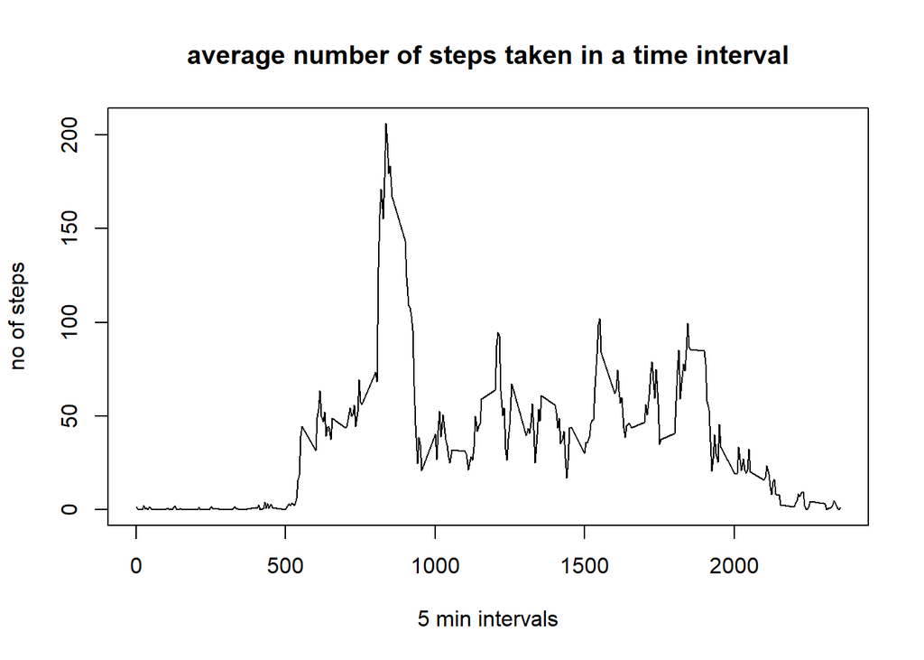

```r
plot(names(day_mean), day_mean, type = "l", xlab = "5 min intervals", ylab = "no of steps", main = "average number of steps taken in a time interval")
```

5 minute interval containing the maximum average number of steps across all days

```r
day_mean[which(day_mean==max(day_mean))]
```

```
##      835
## 206.1698
```

## Imputing missing values

Calculating the total number of missing values

```r
totalna <- sapply(activity$steps,is.na)
sum(totalna)
```

```
## [1] 2304
```

Filling all the missing values with the average number of steps taken for that 5 min interval and creating a new dataset which is identical to the original dataset with missing values filled

```r
activity_new <- activity
for( i in 1:length(activity_new$steps)){
  if(is.na(activity_new$steps[i])){
    activity_new$steps <- replace(activity_new$steps,i,day_mean[as.character(activity_new$interval[i])])
  }
}
head(activity_new)
```

```
##       steps       date interval
## 1 1.7169811 2012-10-01        0
## 2 0.3396226 2012-10-01        5
## 3 0.1320755 2012-10-01       10
## 4 0.1509434 2012-10-01       15
## 5 0.0754717 2012-10-01       20
## 6 2.0943396 2012-10-01       25
```

Histogram for the total number of steps taken everyday for the new dataset

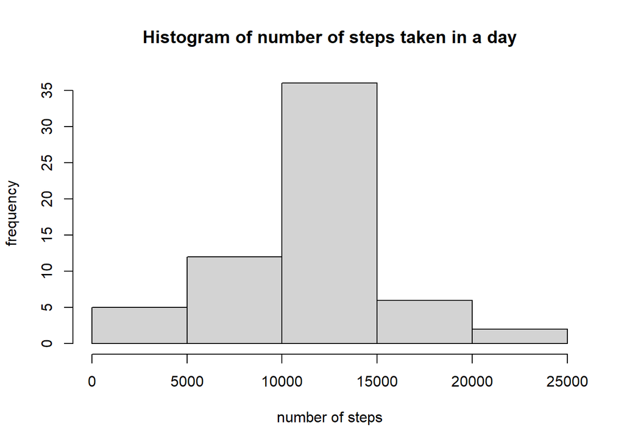

```r
steps_day_new <- tapply(activity_new$steps,activity_new$date,sum,na.rm=TRUE)
hist(steps_day_new, xlab = "number of steps", ylab="frequency", main="Histogram of number of steps taken in a day")
```

Barplot

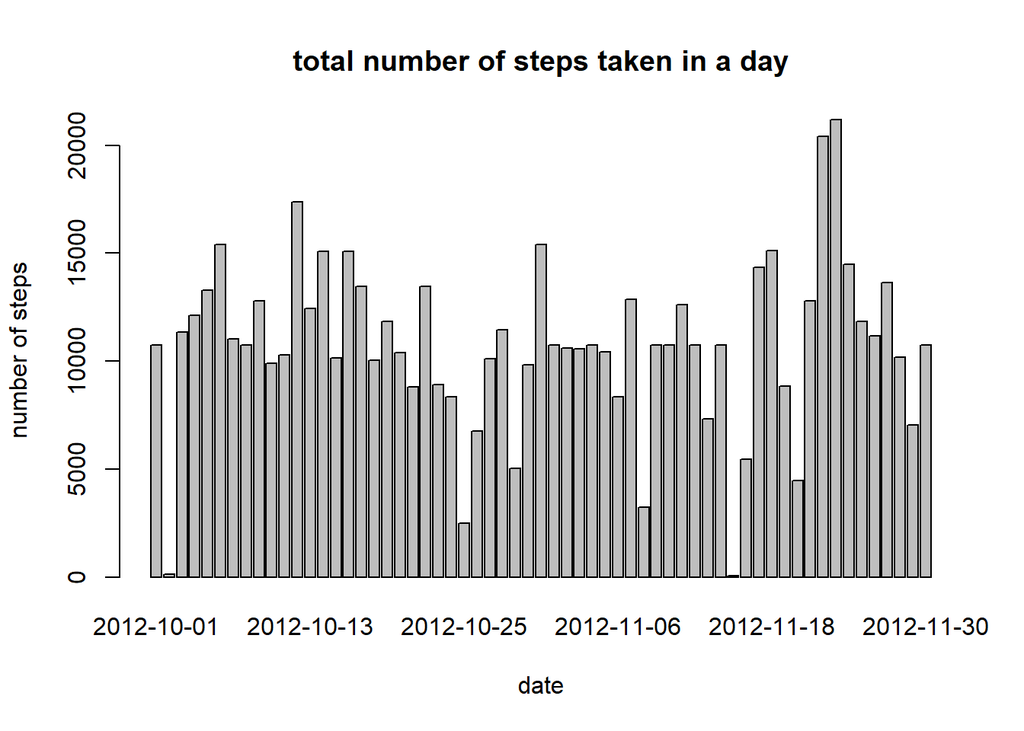

```r
barplot(height = steps_day_new, xlab = "date", ylab = "number of steps", main = "total number of steps taken in a day")
```

Mean of steps taken everyday for the new dataset

```r
mean(steps_day_new)
```

```
## [1] 10766.19
```

Median of steps taken everyday for the new dataset

```r
median(steps_day_new)
```

```
## [1] 10766.19
```

Therefore we can conclude that the mean and median are higher when the missing values are filled with the average number of steps for that 5 minute interval

```r
activity_new$day <- mutate(activity_new, day=weekdays(activity_new$date))
weekdays <- c("Monday","Tuesday","Wednesday","Thursday","Friday")
activity_new$day <- factor((weekdays(activity_new$date) %in% weekdays),
                       levels=c(FALSE, TRUE), labels=c('Weekend', 'Weekday'))
```

Making a panel plot containing a time series plot of the 5 minute interval and the average number of steps taken in a day across all the weekdays and weekends.

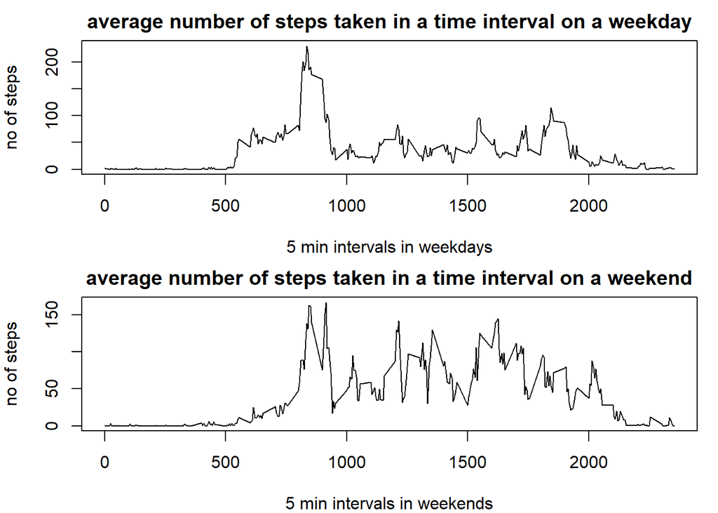

```r
weekday <- subset(activity_new,day=="Weekday")
weekend <- subset(activity_new, day=="Weekend")

steps_weekday_avg <-tapply(weekday$steps, weekday$interval, mean)
steps_weekend_avg <-tapply(weekend$steps, weekend$interval, mean)

par(mfrow=c(2,1), mar=c(4,4,2,1))
plot(names(steps_weekday_avg), steps_weekday_avg, type = "l", xlab = "5 min intervals in weekdays", ylab = "no of steps", main = "average number of steps taken in a time interval on a weekday")
plot(names(steps_weekend_avg), steps_weekend_avg, type = "l", xlab = "5 min intervals in weekends", ylab = "no of steps", main = "average number of steps taken in a time interval on a weekend")
```